# AWRL6844 Intrusion Detection User Guide

## Overview

This example demonstrates the use of TI 60GHz mmWave sensors for in-cabin sensing applications including Vehicle Intruder Detection (ID), Seat Belt Reminder (SBR) and Child Presence Detection (CPD) use cases. The CPD and SBR will share the same signal processing chain for point cloud generation.

This example is compatible with AWRL6844 devices. For this demo, all the parameters are tuned for center front console mounting. Optimization effort will be needed to achieve best performance for additional mounting positions.

> 📝 *NOTE*  
> Any EVM information, visualizer usage, and sensor mounting applies to intruder detection, SBR and CPD.

It is recommened to see the Intrusion Detection tuning document for details on the intruder detection aspect, which can be found here: Intrusion Detection Parameter Tuning. This guide will focus on quickly getting started with the intrusion detection demo.

This guide will focus on quickly getting started with the intrusion detection demo.

## Requirements

### Hardware Requirements

| Item | Details |
| --- | --- |
| AWRL6844 Evaluation Board | [AWRL6844 Evaluation Board](https://www.ti.com/tool/AWRL6844EVM) |
| Computer | PC with Windows 10 or 11. If a laptop is used, please use the ‘High Performance’ power plan in Windows. |
| Micro USB Cable | Due to the high mounting height of the EVM, a 15ft+ cable or USB extension cable is recommended. |

### Software Requirements

| Tool | Version | Download Link |
| --- | --- | --- |
| TI mmWave SDK | 6.0.5.1 | [TI MMWAVE-L-SDK](https://www.ti.com/tool/MMWAVE-L-SDK) |
| MATLAB Runtime | 2024b (24.2) | [MATLAB Runtime - use R2024b only](https://www.mathworks.com/products/compiler/matlab-runtime.html) |

### Getting familiar with the device

> *xWRL6844 Getting Started Guide*  
> Before continuing with this demo, users should first go through the Getting Started Guide for the EVM if they have not already. This will enable users with running the sensor for the first time, loading a applications and gain familiarity various tools used across all labs in the Radar Toolbox.

### Calibration

In order to get the best detection performance, users should run the Range Bias and Rx Channel Gain/Phase Measurement and Compensation procedure to get the calibration coefficients for their Antenna Module and replace the default coefficients in the desired configuration file which can be found in `<Radar_Toolbox>\tools\visualizers\AWRL6844_Incabin_GUI\src\chirpConfigs6844` with the values returned by the calibration procedure.

The following command in the chirp configuration file needs to be updated with the calibrated values.

```
compRangeBiasAndRxChanPhase 0 1 0 1 0 1 0 1 0 1 0 1 0 1 0 1 0 1 0 1 0 1 0 1 0 (This is the default command)
```

The updated command will look similar to the following (but with different values)

```
compRangeBiasAndRxChanPhase `0.1044657 -0.11493 0.79419 -0.13123 -0.83478 -0.08484 -0.77560 0.04535 0.72226 0.09491 0.81415 -0.41129 -0.69214 -0.27069 -0.64630 0.20770 0.63818 0.67627 0.69116 -0.90146 -0.43289 -0.81061 -0.48209 0.72995 0.50214
```

At minimum, change the first parameter to 0.1 to account for an estimated Range Bias for this EVM.

```
compRangeBiasAndRxChanPhase 0.1 1 0 1 0 1 0 1 0 1 0 1 0 1 0 1 0 1 0 1 0 1 0 1 0
```

To run the calibration procedure, please follow the instructions provided in the MMWAVE-L-SDK-6 documentation: [Rx Gain Measurement Compensation](https://dev.ti.com/tirex/explore/content/MMWAVE_L_SDK_06_00_05_01/docs/api_guide_xwrL684x/MMWAVE_DEMO.html#Rx_Gain_Measurement_Compensation).

## Quickstart

### 1. Configure the EVM for Flashing Mode

Instructions for EVM setup for Flashing mode can be found in the EVM Setup Guide

### 2. Flash the EVM using Uniflash

Flash the binary listed below using Uniflash. Follow the instructions found in the Using Uniflash Guide  
`<Radar_Toolbox>\source\ti\examples\Automotive_InCabin_Security_and_Safety\AWRL6844_InCabin_Demos\prebuilt_binaries\demo_in_cabin_sensing_6844_system.release.appimage`

### 3. Configure the EVM for Functional Mode

Instructions for EVM setup for Functional mode can be found in the EVM Setup Guide

### 4. Mount the EVM and Create Test Environment

Mount the sensor at the desired location securely so that the sensor is stable during runtime. Update the desired configuration file so that it reflects the device’s location. More information on mounting can be found in the section below.

### 5. Launch the Visualizer

> ⚠️ *MATLAB Runtime Version R2024b (24.2)*  
> **Exact version** [R2024b (24.2)](https://www.mathworks.com/products/compiler/matlab-runtime.html) required.
1. Launch the visualizer executable located at `<Radar_Toolbox>\tools\visualizers\AWRL6844_Incabin_GUI\src\`
2. Double click to launch **occupancy_demo_gui.exe**.
3. A black console window will appear. After 30-60sec, a configuration window will appear as shown below.

[figure not shown]

### 6. Config Visualizer

1. The COM ports will be auto-populated. Users should confirm or change as needed.
2. (Optional) Select and enable the webcam if it is connected to the PC
3. You should see the Chirp configuration file automatically selected in the Configuration dialogue. But if the configuration file is not the correct one, browse to select a file provided in the config_file directory: `<Radar_Toolbox>\tools\visualizers\AWRL6844_Incabin_GUI\src\chirpConfigs6844`
   - See notes section below for more information
4. After verifying all the information is correct, press **Done** to start the Visualizer.
5. The Visualizer window will appear as shown below.

[figure not shown]

6. The visualizer window will start outputting the occupancy signals. After 20 frames (as a default setting), the demo will start output the occupancy decisions. The trigger alarm will cover the car if there is an intrusion, additionally the box being intruded in will highlight red.

#### Configuration Notes:

1. The same demo binary will be able to support both Intruder Detection and Seatbelt Reminder mode by loading different configuration file.
2. There are two configurations for the intruder demo. Both contain the low power implementation however please note the following differences:
   - *intrusion_detection_LP.cfg* is configured with a lower powwer consumption with a slightly worse performance.
   - *intrusion_detection.cfg* is slightly higher in power consumption and better performance.

### 7. Understand the Visualizer

The Visualizer window is divided into seven panels as shown in the annotated picture here.

[figure not shown]

1. **Statistics**: This section prints real-time information from the target: Frame number, total number of detected points and occupancy status. Processing time is not provided at this time.
2. **Chirp Configuration**: This panels shows the static chirp configuration loaded at startup time.
3. **Control**: This panel provides an Exit button and a Pause button.
4. **Scene Plot**: This panel displays the occupancy boxes as defined in the config file as well as the occupancy decisions per box. Users can modify the zone definition as needed. Users can rotate the figure to see 2D and 3D figure.
5. **Occupancy Signal**: This panel display the occupancy signal that determines whether an intrusion has occured.
6. **Heatmap, SNR and Range Profile**: The SNR heatmap can be enabled in the .cfg file by decreasing frame rate and enabling the heatmap. More instructions on how to do this can be found in Step 3 of the Tuning. The range profile is currently not supported.
7. **Ground Truth Video**: A camera video can be included to the visualizer to serve as the groud truth video. However, we have observed some delays with this feature enabled.

> 📝 *NOTE*  
> By default, the TLV output data for each frame will be saved automatrically in the subfolder `<Radar_Toolbox>\tools\visualizers\AWRL6844_Incabin_GUI\src\fHistFiles\fHistFiles` as `fHistRT_0000.mat`, `fHistRT_0001.mat` and etc. Each file will contain TLV results for 1000 frames. These files will be overwritten at the next run. Users need to move them to avoid data files from being overwritten.

## Algorithm Overview

Please see Intrusion Detection Parameter Tuning for details.

## EVM Mounting and Coordinate Transforms

The detected point cloud is all relative to the sensor. In order to make occupancy decision for each seat in the car, we need to transform the point cloud from sensor coordinates to the car coordinates. The car coordinate is plotted in the figure below.

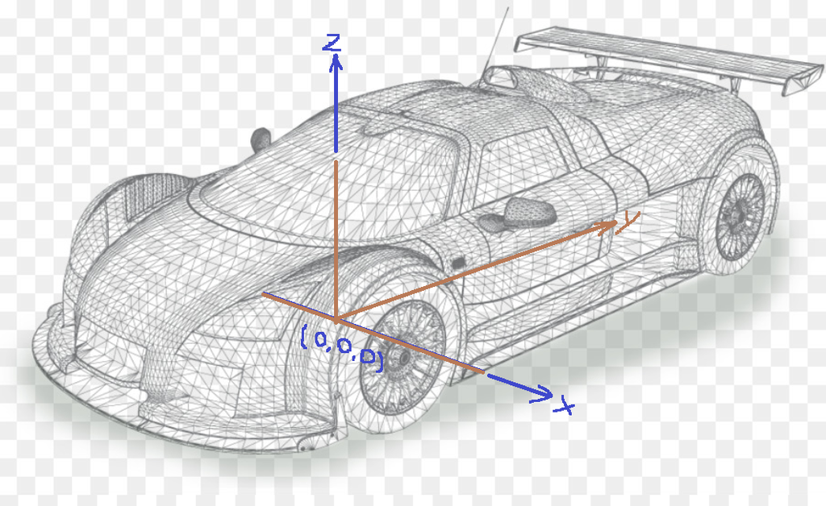

Since the point cloud will be transform to this car coordinates, the zone definition for each seat need to follow this car coordinates as well.

- For x direction, 0 represents the center of the car, the driver side X values are positive, the passenger side are negative;
- For y direction, 0 represents front window.
- For z direction, 0 represents the car floor.

There are different position and different mounting angle that can be considered for mounting the device. To give the full flexibility, “sensorPosition” CLI is used to indicate the mounting offset in (x, y, z) and mounting rotation angle in x-y plane and y-z plane.

Based on these offsets and tilting angles, the visualizer will transform the point cloud from the sensor coordinate to the car coordinate.

Next we give one example:

- When the sensor is mounted around the center close to the front overhead console and tilted down by 60 degrees, then sensor position should be programmed as: `sensorPosition 0 0.8 1.15 0 -60`

This indicates the sensor is mounted at (x = 0, y = 0.8m, z = 1.15m) and is tilted down by 60 degree in y-z domain to facing the floor. Please referred to the figure below to help understanding.

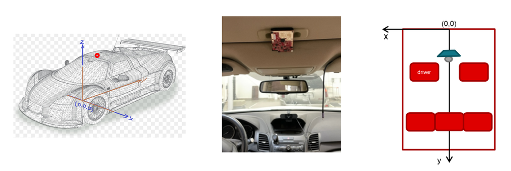

## Antenna Configuration

This demo supports different antenna layouts. In this package, we only provided an example configurations with the TI xWRL6844 EVM module. The ODS Antenna is shown in the following image along with the virtual antenna array.

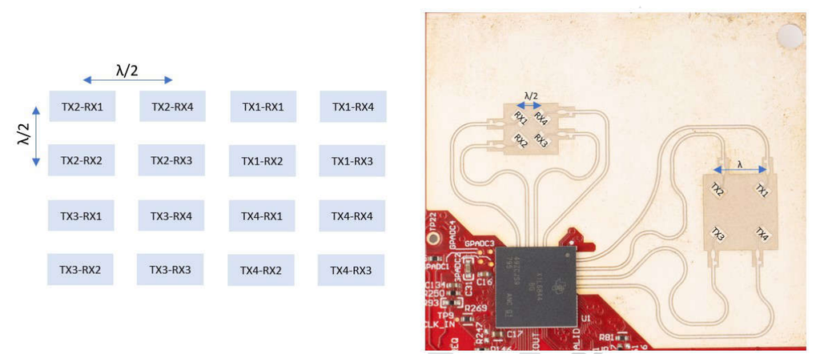

antGeometry0 -2 -2 -3 -3 0 0 -1 -1 0 0 -1 -1 -2 -2 -3 -3  
antGeometry1 0 -1 -1 0 0 -1 -1 0 -2 -3 -3 -2 -2 -3 -3 -2  
antPhaseRot 1 1 1 1 1 1 1 1 1 1 1 1 1 1 1 1

## Zone Definition

The interior of the vehicle is divided into occupancy boxes as illistrated below.

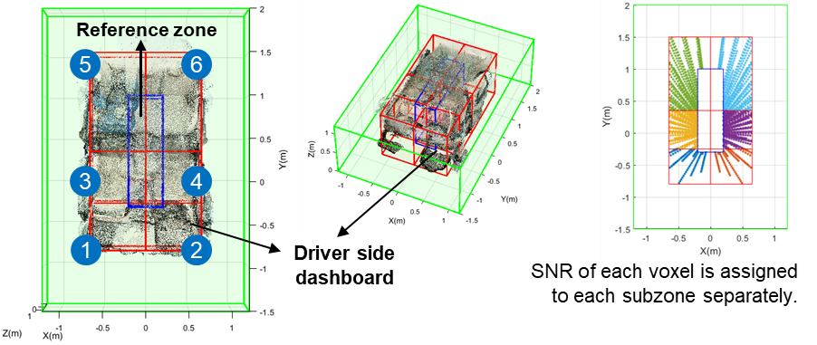

- Occupancy Box 0: Reference zone where no intrusion expected
- Occupancy Box 1: Front passenger side dashboard
- Occupancy Box 2: Front driver side dashboard
- Occupancy Box 3: Front passenger seat zone
- Occupancy Box 4: Front driver seat zone
- Occupancy Box 5: Rear passenger seat zone
- Occupancy Box 6: Rear driver seat zone

> All the occupancy box definitions follow car coordination

```java
% Intruder detection occupancy box definitions
occupancyBox 0 -0.20 0.20 -0.30 1.00 0.00 1.05
occupancyBox 1 -0.65 0.00 -0.80 -0.25 0.00 1.05
occupancyBox 2  0.00 0.65 -0.80 -0.25 0.00 1.05
occupancyBox 3 -0.65 0.00 -0.25 0.35 0.00 1.05
occupancyBox 4  0.00 0.65 -0.25 0.35 0.00 1.05
occupancyBox 5 -0.65 0.00 0.35 1.50 0.00 1.05
occupancyBox 6  0.00 0.65 0.35 1.50 0.00 1.05
```

## Demo Configuration File Parameters

Please see Section 2 “Configuration Parameters” of Intrusion Detection Parameter Tuning for details.

## Tuning

The recommended procedure to tune this demo is as follows:

### 1. Run the demo with no changes

Using the default configuration file with the proper mounting position:

- **Proper mounting** - The classifer model has been trained with the sensor mounted at the front overhead console position.  
  `% Sensor position and tilt angles`  
  `% sensorPosition <xOffset> <yOffset> <zOffset> <azimuthTilt> <elevationTilt>`  
  `sensorPosition 0 0.8 1.15 0 -60`
- The performance will be similar to our findings when the sensor being mounted is in a similar position and a similar tilting angle even in different cars. For other positions like center mount, side mount, and back mount, the performance has not been tested at this time.
- If the dimensions of the car being evaluated require a different sensor position than the default, we still recommend running the default configuration and updating the xOffset and yOffset after evaluating the performance.

### 2. Identify weaknesses and tune based on behavior

  Simulate intrusions by touching each seat, the floor, the dashboard in front of the car, and any additional tests that are important for performance.

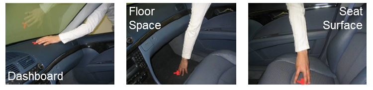

#### 2A. If there are false detections then take the following measures:

- Reduce the volume of the occupancy zones if intrusions are occuring when you are in the proximity of the car.  
  `% occupancyBox <occupancyBox Index> <xMin> <xMax> <yMin> <yMax> <zMin> <zMax>`  
  `occupancyBox 1 -0.55 0.00 -0.80 -0.25 0.00 1.05`
- Increase activation level required for intrustion if the signal is stronger and more sensitive.  
  `% intruderDetAdvCfg <zoneIndex> <threshold> <free2ActiveCntr> <active2FreeCntr> <localPeakCheck> <sideLobeThre> <peakExpSamples>`  
  `intruderDetAdvCfg 1 8 2 10 2 0.9 2`

Generally, it is recommended to try one change at a time. We recommend changing the occupancy box location first if the dimensions of your car are significantly different than the default. Otherwise, it is best to start with the activation level.

#### 2B. If there are no detections then take the following measures:

- Reduce the activation level required if the signal is weaker than other respective boxes - i.e., change the `threshold` parameter of `intruderDetAdvCfg`

### 3. Use SNR Heatmap (optional)

  The SNR heatmap can be useful in many ways while tuning. In the case that you are are not seeing any signal or seeing random intrusions then you can use the heatmap to identify whether your occupancy boxes are defined in the wrong locations or if your sensor position is incorrect.

Steps to turn on the SNR heatmap:

1. Reduce the frame rate to 1000 ms by modifying the frame periodicity (100 ms is the default).  
   `% frameCfg <numChirpsInBurst> <numChirpAcc> <BurstPeriodicity> <NumOfBurstsInFrame> <FramePeriodicty> <numOfFrames>`  
   `frameCfg 16 0 1400 1 1000 0`
2. Turn on the SNR heatmap:  
   `% dbgGuiMonitor <dbgDetMat3D> <dbgDetSnr3D>`  
   `dbgGuiMonitor 0 1 0 0 0 0 0`
3. Re-run the demo using this updated configuration

**NOTE**: The SNR heatmap requires a large amount of data to be processed which causes the GUI to be delayed and is why we reduce the frame rate.

### General Notes:

#### Definitions:

- **Accurate zone definition** - Ensuring the zones align with the physical space of the vehicle. For simplicity, we would suggest to start with the default zone definition in the example configuration file and adjust as needed.
- **Matching Antenna Pattern** - Make sure antGeometry0, antGeometry1 and antPhaseRot settings in the configuration file matches with the antenna pattern on the device/EVM.
- **Per occupany box thresholds** - Each occupancy box can have an individually tuned intrusion threshold. This can be used to adjust the sensitivy according to observed levels of false positives and missed detections.

**NOTE**: We have a Parameter Tuning Guide for the Intrusion Detection Demo which will be far more in depth and cover all the tuning parameters.

## Developer’s Guide

### 1. Import Demo Project

To import the source code into your CCS 20 workspace, a CCS project is provided in the example at the path given below.

- Start CCS 20 and configure your workspace as desired.
- Import the projects specified in the following folder to CCS. `<Radar_Toolbox>\source\ti\examples\Automotive_InCabin_Security_and_Safety\AWRL6844_InCabin_Demos\src\`
- Verify that the import occurred without error by checking that `demo_in_cabin_sensing_68xx_system` and `demo_in_cabin_sensing_68xx_mss` show up in the project explorer

> ⚠️ *Error during Import to IDE*  
> If an error occurs, check that the software dependencies listed above have been installed. Errors will occur if necessary files are not installed in the correct location for importing.

### 2. Build the Demo

1. Select the **demo_in_cabin_sensing_68xx_system** project in the **Project Explorer** so that it is highlighted. Right click on the project and select **Rebuild Project**. The project will then build.
2. Select the **demo_in_cabin_sensing_68xx_mss** project in the **Project Explorer** so that it is highlighted. Right click on the project and select **Rebuild Project**. The project will then build.
3. On successful build, the following should appear in `<PROJECT_WORKSPACE_DIR>\demo_in_cabin_sensing_68xx_mss\default`
   - **demo_in_cabin_sensing_68xx_mss.xer4f** (this is the Cortex R4F binary used for CCS debug mode)
   - **demo_in_cabin_sensing_68xx.appimage** (this is the flashable binary used for deployment mode)

> ⚠️ *Building vs Rebuiling*  
> Selecting Rebuild instead of Build ensures that the project is always re-compiled. This is especially important in case the previous build failed with errors.

> ⚠️ *Build Fails with Errors*  
> If the build fails with errors, please ensure that all the software requirements are installed as listed above and in the mmWave SDK release notes.

> **Note**  
> As mentioned in the Quickstart section, pre-built binary files are provided in the pre-compiled directory of the example.

> **Note**  
> Images can be built in either debug mode or release mode. Debug mode will face some performance limitations due to the un-optimized DSP implementation in debug mode

### 3. Execute the Demo

There are two ways to execute the compiled code on the EVM:

- **Deployment mode**: the EVM boots from flash and starts running the bin image at power-up
  - Using the MMWAVE-L-SDK Visualizer, flash the **demo_in_cabin_sensing_68xx.appimage** found at `<PROJECT_WORKSPACE_DIR>\demo_in_cabin_sensing_68xx_mss\default`
  - The same procedure for flashing can be used as detailed in the Flash the EVM section.
- **Debug mode**: This mode is used for downloading and running the executable from CCS 20. This mode enables JTAG connection with CCS 20 while the example is running and is useful during development and debugging.
  - Follow the CCS 20 Debug Mode Guide

After executing the example using either method, launch the visualizer and proceed as described under Quickstart

## Need More Help?

- Search for your issue or post a new question on the [mmWave E2E forums](https://e2e.ti.com/support/sensor/mmwave_sensors/f/1023)
- See the SDK for more documentation on various algorithms used in this demo.